# R Notebook

# Loading packages

```r
library(tidyverse)
```

```r
library(BiocManager)
```

```r
library(readr)
```

```r
library(DESeq2)
```

```r
library(RColorBrewer)
```

```r
library(pheatmap)
```

```r
library(tidyverse)
```

# Loading Data

```r
counts_raw <- read.delim("data/KC-Tie2_kidney_Gene_counts.txt", header = TRUE, sep = "\t", dec = ".")
```

[output not shown]

# Reshaping Data

```r
# Remove the first two columns containing annotations - sample name and genotype
```

[output not shown]

```r
counts_data <- counts_raw[,-(1)]
```

[output not shown]

```r
# Store Ensembl Gene ID as rownames
```

[output not shown]

```r
gene_IDs <- colnames(counts_data)
```

[output not shown]

```r
# Transpose counts matrix
```

[output not shown]

```r
counts_data <- t(counts_data)
```

[output not shown]

```r
# Add sample IDs as column names
```

[output not shown]

```r
colnames(counts_data) <- counts_raw[,1]
```

[output not shown]

```r
# Now I have the raw counts matrix in the format of each row contains a gene and each column contains a sample
```

[output not shown]

```r
head(counts_data,2)
```

```
                   9239-ZC-0007_S1 9239-ZC-0010_S1 9239-ZC-0009_S1 9239-ZC-0011_S1 9239-ZC-0008_S1 9239-ZC-0012_S1
ENSMUSG00000000001            1834            1643            1394            2204            2242            2203
ENSMUSG00000000028              21              41              21              45              34              32
```

[output not shown]

```r
# Making sample metadata into correct matrix format
rownames(sample_metadata) <- sample_metadata[,1]

sample_metadata <- sample_metadata %>%
  select(!Sample.name)
```

Examine the count matrix and column data to see if they are consistent in terms of sample ID:

```r
all(rownames(sample_metadata) %in% colnames(counts_data))
```

```
[1] TRUE
```

Examine the count matrix and column data to see if they are consistent in terms of sample order:

```r
all(rownames(sample_metadata) == colnames(counts_data))
```

```
[1] FALSE
```

Reorder columns of count matrix to be the same as the order of samples in metadata:

```r
counts_data <- counts_data[, rownames(sample_metadata)]

all(rownames(sample_metadata) == colnames(counts_data))
```

```
[1] TRUE
```

# Creating DESeq Object

```r
dds <- DESeqDataSetFromMatrix(countData = round(counts_data),
                              colData = sample_metadata,
                              design = ~ Genotype)
```

```
Warning: some variables in design formula are characters, converting to factors  Note: levels of factors in the design contain characters other than
  letters, numbers, '_' and '.'. It is recommended (but not required) to use
  only letters, numbers, and delimiters '_' or '.', as these are safe characters
  for column names in R. [This is a message, not a warning or an error]
```

```r
dds
```

```
class: DESeqDataSet
dim: 17549 6
metadata(1): version
assays(1): counts
rownames(17549): ENSMUSG00000000028 ENSMUSG00000000049 ... ENSMUSG00002076809 ENSMUSG00002076896
rowData names(0):
colnames(6): 9239-ZC-0007_S1 9239-ZC-0008_S1 ... 9239-ZC-0011_S1 9239-ZC-0012_S1
colData names(1): Genotype
```

## Normalization

Calculating size factors used for normalization using the `estimateSizeFactors()` function and viewing using the `sizeFactors()` function:

```r
dds <- estimateSizeFactors(dds)
```

```
  Note: levels of factors in the design contain characters other than
  letters, numbers, '_' and '.'. It is recommended (but not required) to use
  only letters, numbers, and delimiters '_' or '.', as these are safe characters
  for column names in R. [This is a message, not a warning or an error]
```

```r
sizeFactors(dds)
```

```
9239-ZC-0007_S1 9239-ZC-0008_S1 9239-ZC-0009_S1 9239-ZC-0010_S1 9239-ZC-0011_S1 9239-ZC-0012_S1
      0.9518866       1.2108208       0.7389597       0.9004852       1.1996383       1.1019929
```

### Extracting normalized counts

```r
normalized_counts_data <- counts(dds, normalized = TRUE)
```

# Exploratory Data Analysis

## Unsupervised Clustering

### Hierarchical Heat map Analysis

When using these visualization methods, we should first log transform the normalized counts to improve the visualization of the clustering. For RNA-Seq data, DESeq2 uses a variance stabilizing transformation (VST), which is a logarithmic transformation that moderates the variance across the mean. We can transform the normalized counts by using the DESeq2 vst() function on the DESeq2 object. The blind=TRUE argument specifies that the transformation should be blind to the sample information given in the design formula; this argument should be specified when performing quality assessment.

```r
# log transform the normalized counts
log_dds <- vst(dds, blind = TRUE)
```

Hierarchical clustering with heatmaps is used to assess the similarity in gene expression between the different samples in a dataset. This technique is used to explore how similar replicates are to each other and whether the samples belonging to different sample groups cluster separately. The heatmap is created by using the gene expression correlation values for all pairwise combinations of samples in the dataset, with the value 1 being perfect correlation. The hierarchical tree shows which samples are more similar to each other and the colors in the heatmap depict the correlation values. We expect the biological replicates to cluster together and sample conditions to cluster apart. Since the majority of genes should not be differentially expressed, samples should generally have high correlations with each other.

```r
# Extract the vst matrix (containing log-transformed count values) from the DESeq object
log_dds_mat <- assay(log_dds)

# Compute correlation matrix
log_dds_cor <- cor(log_dds_mat)

# Plot heatmap
pheatmap(log_dds_cor, annotation = select(sample_metadata, Genotype))
```

[output not shown]

### Principal Component Analysis (PCA)

```
using ntop=500 top features by variance
```

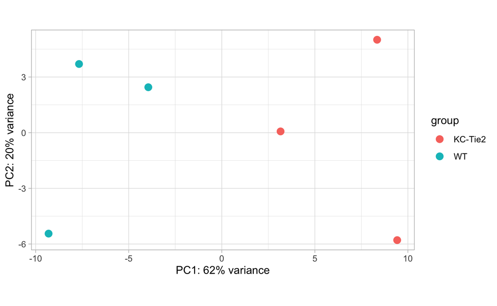

```r
# Plot PCA
plotPCA(log_dds, intgroup = "Genotype") +
  theme_light()
```

- PC1 explains 62% of the variance
- KC-Tie2 samples and WT samples separate decently well by PC1
- There may be other sources of variance to explore

# Differential Expression Analysis

The differential expression analysis with DESeq2 consists of roughly three steps: fitting the raw counts for each gene to the DESeq2 negative binomial model and testing for differential expression, shrinking the log2 fold changes, and extracting and visualizing the results.

## Run DEA

```r
# Run DE analysis
dds <- DESeq(dds)
```

```
  Note: levels of factors in the design contain characters other than
  letters, numbers, '_' and '.'. It is recommended (but not required) to use
  only letters, numbers, and delimiters '_' or '.', as these are safe characters
  for column names in R. [This is a message, not a warning or an error]
```

### Exploring how well our data fit the model

For RNA-Seq data, the variance is generally expected to increase with the gene’s mean expression. To observe this relationship, we can calculate the means and variances for every gene of the normal samples using the apply() function.

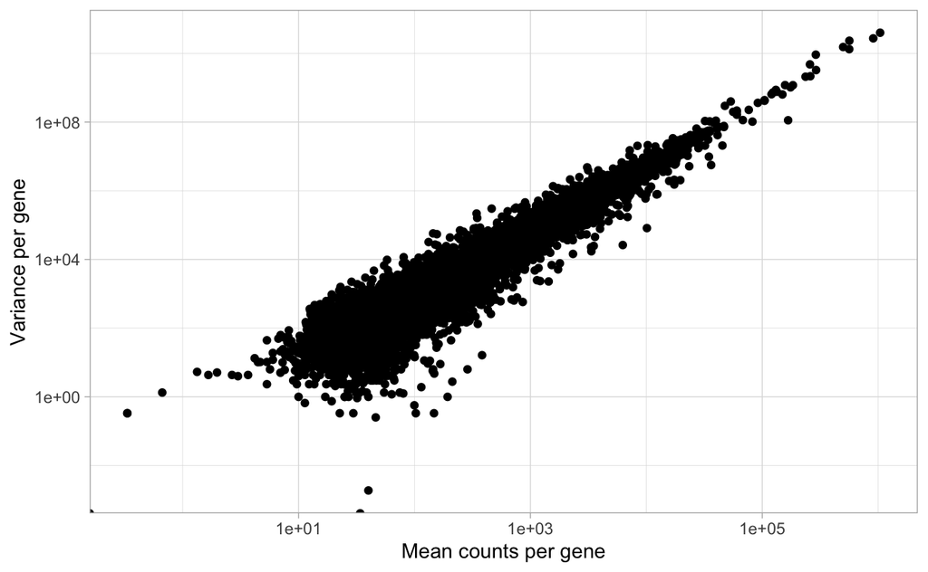

```r
# Calculating mean for each gene (each row) of only WT samples
mean_counts <- apply(counts_data[,1:3], 1, mean)

# Calculating varaince for each gene (each row) of only WT samples
var_counts <- apply(counts_data[,1:3], 1, var)

# Creating df with mean and variance for each gene
df_mean_var <- data.frame(mean_counts, var_counts)

# Plotting
ggplot(df_mean_var) +
  geom_point(aes(x = mean_counts, y = var_counts)) +
  scale_x_log10() +
  scale_y_log10() +
  labs(x = "Mean counts per gene",
       y = "Variance per gene") +
  theme_light()
```

We see the variance in gene expression increases with the mean. This is expected for RNA-Seq data. Also, note how the range in values for variance is greater for lower mean counts than higher mean counts. This is also expected for RNA-Seq count data. A measure of the variance for a given mean is described by a metric called dispersion in the DESeq2 model. The DESeq2 model uses dispersion to assess the variability in expression when modeling the counts.

#### Dispersion

To plot the dispersions relative to the means for each gene, we can use the plotDispEsts() function on the DESeq2 object. Each black dot is a gene with associated mean and dispersion values. We expect dispersion values to decrease with increasing mean, which is what we see. With only a few replicates for RNA-Seq experiments, gene-wise estimates of dispersion are often inaccurate, so DESeq2 uses information across all genes to determine the most likely estimates of dispersion for a given mean expression value, shown with the red line in the figure. Genes with inaccurately small estimates of variation could yield many false positives, or genes that are identified as DE, when they are really not. Therefore, the original gene-wise dispersion estimates, shown as the black dots in the figure, are shrunken towards the curve to yield more accurate estimates of dispersion, shown as blue dots. The more accurate, shrunken dispersion estimates are used to model the counts for determining the differentially-expressed genes. Extremely high dispersion values, shown surrounded by blue circles, are not shrunken, due to the likelihood that the gene may have higher variability than others for biological or technical reasons and reducing the variation could result in false positives. The strength of the shrinkage is dependent on the distance from the curve and sample size. Larger numbers of replicates can estimate the mean and variation more accurately, so yield less shrinkage.

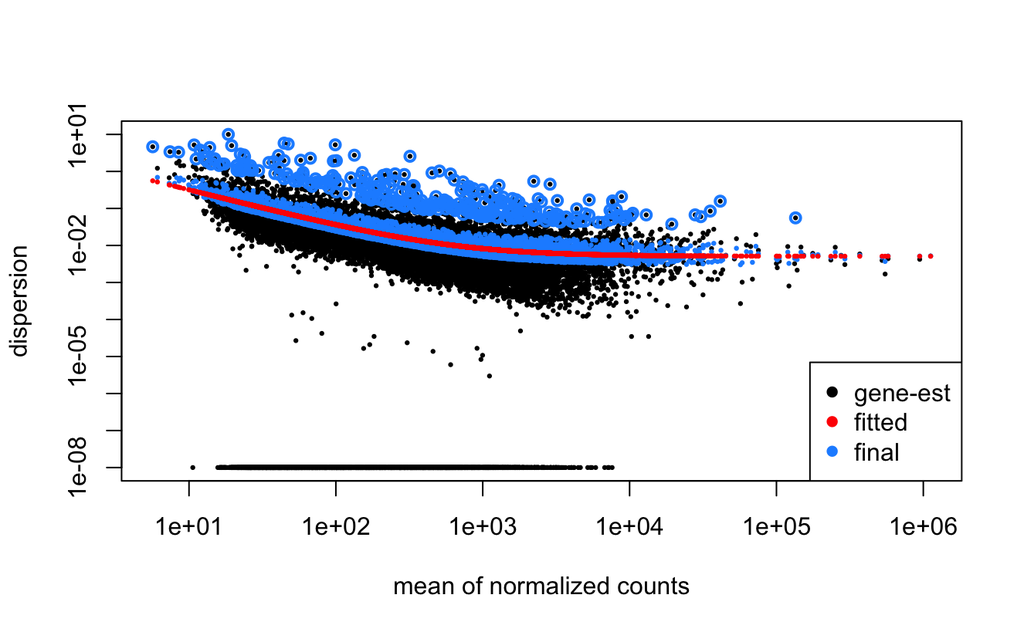

```r
# Plot dispersion estimates
plotDispEsts(dds)
```

- My plot looks ok
- The assumptions of DESeq2 are met since the dispersions decrease with increasing mean and the raw dispersions seem to cluster around the maximum likelihood line.

## Extracting DEA Results

```r
# Extract all results
dds_results <- results(dds)
```

## Log2 Fold-Change Shrinkage

```r
# Perform log2 fold-change shrinkage on results of DEA
dds_results <- lfcShrink(dds,
                         coef = "Genotype_KC.Tie2_vs_WT",
                         res = dds_results)
```

[output not shown]

## Exploring Results

```r
mcols(dds_results)
```

```
DataFrame with 6 rows and 2 columns
                       type            description
                <character>            <character>
baseMean       intermediate mean of normalized c..
log2FoldChange      results log2 fold change (ML..
lfcSE               results standard error: Geno..
stat                results Wald statistic: Geno..
pvalue              results Wald test p-value: G..
padj                results   BH adjusted p-values
```

- In DESeq2 the FDR-corrected p-values are called padj
- DESeq2 performs multiple test correction using the Benjamini–Hochberg (BH) procedure as the default FDR method

```r
head(dds_results,10)
```

```
log2 fold change (MLE): Genotype WT vs KC.Tie2
Wald test p-value: Genotype WT vs KC.Tie2
DataFrame with 10 rows and 6 columns
                    baseMean log2FoldChange     lfcSE       stat     pvalue      padj
                   <numeric>      <numeric> <numeric>  <numeric>  <numeric> <numeric>
ENSMUSG00000000028   31.7734     -0.5082358 0.3916370 -1.2977216 0.19438301 0.7100434
ENSMUSG00000000049   67.0795      0.4084933 0.4089584  0.9988627 0.31786120 0.8238879
ENSMUSG00000000056 1169.8272     -0.0135033 0.1108314 -0.1218360 0.90302890 0.9880152
ENSMUSG00000000058  714.0912     -0.1644836 0.1223982 -1.3438396 0.17900026 0.6888449
ENSMUSG00000000078  856.5002     -0.4365348 0.1410050 -3.0958825 0.00196228 0.0498779
ENSMUSG00000000085  566.7791      0.0706429 0.1224237  0.5770359 0.56391520 0.9307459
ENSMUSG00000000088 3384.2653     -0.2025984 0.0846180 -2.3942691 0.01665353 0.2063226
ENSMUSG00000000093 1636.9874     -0.0744040 0.0909554 -0.8180276 0.41334141 0.8748665
ENSMUSG00000000120   39.1557     -0.0103156 0.3756771 -0.0274588 0.97809381 0.9978896
ENSMUSG00000000126   44.5467      0.0922518 0.3682020  0.2505468 0.80216451 0.9708647
```

```r
# summary() provides the number of differentially-expressed genes
summary(dds_results)
```

[output not shown]

### Annotate with Gene Names and Descriptions

```r
#install.packages("devtools")
#devtools::install_github("stephenturner/annotables")

library(annotables)

# Convert results matrix to a df and change row names (genes) to a column
dds_results_all <- data.frame(dds_results) %>%
  rownames_to_column(var = "ensgene")

# Merge results with gene names and descriptions
dds_results_all <- left_join(
                        x = dds_results_all,
                        y = grcm38[,c("ensgene","symbol","description")],
                        by = "ensgene")

head(dds_results_all,2)
```

[output not shown]

### Extract Signficant DE Genes

```r
# Extract all genes with padj < 0.05
dds_results_signif <- subset(dds_results_all, padj < 0.05)
dds_results_signif <- dds_results_signif %>%
  arrange(padj)

head(dds_results_signif,10)
```

|  | ensgene | baseMean | log2FoldChange | lfcSE | pvalue | padj | symbol | description |
| --- | --- | --- | --- | --- | --- | --- | --- | --- |
| 1 | ENSMUSG00000058952 | 415.52223 | 3.7086105 | 0.1929320 | 1.570690e-83 | 2.755619e-79 | Cfi | complement component factor i |
| 2 | ENSMUSG00000073418 | 1925.28770 | 5.0006011 | 0.3314310 | 1.279079e-52 | 1.122008e-48 | C4b | complement component 4B (Chido blood group) |
| 3 | ENSMUSG00000035540 | 572.08748 | 1.8912034 | 0.1297734 | 2.985016e-49 | 1.745637e-45 | Gc | vitamin D binding protein |
| 4 | ENSMUSG00000057074 | 454.45829 | -4.9282939 | 0.4201519 | 4.472690e-33 | 1.961722e-29 | Ces1g | carboxylesterase 1G |
| 5 | ENSMUSG00000029716 | 73.97631 | 4.4616751 | 0.4311313 | 1.191124e-25 | 4.179417e-22 | Tfr2 | transferrin receptor 2 |
| 6 | ENSMUSG00000017718 | 1010.46012 | -1.1266993 | 0.1119827 | 4.099422e-25 | 1.198671e-21 | Afmid | arylformamidase |
| 7 | ENSMUSG00000040183 | 264.16189 | 1.7842180 | 0.1798605 | 1.937410e-24 | 4.855702e-21 | Ankrd6 | ankyrin repeat domain 6 |
| 8 | ENSMUSG00000040808 | 4886.11600 | 0.9676381 | 0.1018880 | 1.151213e-22 | 2.524611e-19 | S100g | S100 calcium binding protein G |
| 9 | ENSMUSG00000037852 | 598.38472 | -1.5985961 | 0.1767206 | 6.646070e-21 | 1.295541e-17 | Cpe | carboxypeptidase E |
| 10 | ENSMUSG00000061959 | 984.32275 | -0.8776787 | 0.1035544 | 1.235403e-18 | 2.167391e-15 | Ces1e | carboxylesterase 1E |

## Visualizing DEA Results

### Expression Heatmap

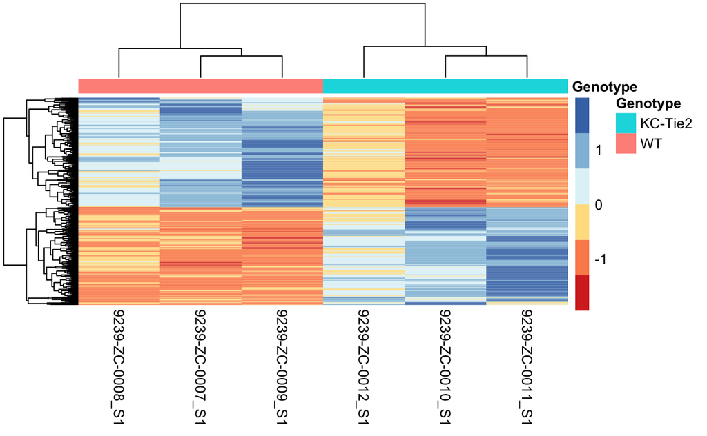

```r
# Subset normalized counts to signficant genes
sig_norm_counts <- normalized_counts_data[dds_results_signif$ensgene,]

# Choose color palette from RColorBrewer
heat_colors <- brewer.pal(6, "RdYlBu")

# Run pheatmap
pheatmap(sig_norm_counts,
         color = heat_colors,
         cluster_rows = T,
         show_rownames = F,
         annotation = select(sample_metadata, Genotype),
         scale = "row")
```

### Volcano Plot

```r
# Obtain logical vector regarding whether padj values are less than 0.05
dds_results_all <- dds_results_all %>%
  mutate(threshold = padj < 0.05)

dds_results_all <- dds_results_all %>%
  mutate(Expression = case_when(
    (log2FoldChange > 0 & padj <= 0.05) ~ "Up-regulated",
    (log2FoldChange < 0 & padj <= 0.05) ~ "Down-regulated",
    TRUE ~ "Unchanged"))

# Making volcano plot
volcano_plot <- ggplot(dds_results_all) +
  geom_point(aes(x = log2FoldChange,
                 y = -log(padj,10),
                 color = Expression),
             size = 3/4) +
  xlab(expression("log"[2]*"FC")) +
  ylab(expression("-log"[10]*"FDR")) +
  scale_color_manual(values = c("dodgerblue3", "gray50", "firebrick3")) +
  guides(colour = guide_legend(override.aes = list(size=1.5)))
  theme(legend.position = "none",
        plot.title = element_text(size = rel(1.5), hjust = 0.5),
        axis.title = element_text(size = rel(1.25)))
```

[output not shown]

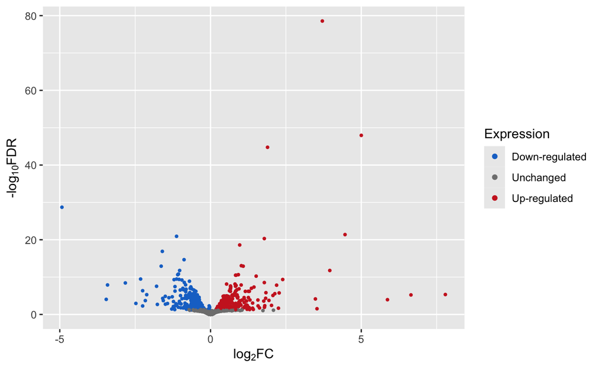

```r
volcano_plot
```

```r
top_20_de_genes <- left_join(x = top_20_de_genes,
                             y = grcm38[,c("ensgene","symbol","description")],
                        by = "ensgene") %>%
  select(!description)
```

[output not shown]

```r
ggplot(top_20_de_genes) +
  geom_point(aes(x = ensgene,
                 y = normalized_counts,
                 color = Genotype)) +
  scale_y_log10() +
  xlab("Genes") +
  ylab("Normalized Counts") +
  ggtitle("Top 20 Signficant Differentially-Expressed Genes")
```

[output not shown]